# Week 6 · Carry checked computation from MATLAB into R

MATH 346 course companion · R

**Note**

Use this chapter with the companion reading guide. **Nothing in this chapter is collected or graded.** The approved syllabus, workload guide and Blackboard remain authoritative.

## Your route

**Can the saved R script recreate its evidence and support its interpretation?**

The familiar ideas transfer: objects, vectors, selectors, formulas and checks. Their syntax changes. Begin with a saved R script and the built-in mtcars data, then turn data, mappings and geometry into checked plots.

The report activity uses a supplied template. R performs calculations; RStudio is the editor; Quarto runs the report code and assembles prose, computed results and figures. Rendering cannot decide whether your explanation is justified.

Before you start · Words used here · Setup · Meeting 1 · Meeting 2 · AI audit · Practice and resources · Chapter list. The page contents navigation also links to the sections.

**TipA first 30-minute recovery session**

Choose a stopping point within about 30 minutes; continue from there next time. This is an untested first-pass budget, not a completion promise.

1. Check prerequisites and setup. If access is blocked, focus on that first.
2. Compare the syntax table and inspect the first data-frame/selector example.
3. Read the scatterplot mappings, units and layer-count check.
4. Try the second self-check, then continue the relevant Core 5/6 task. Rendering the supplied report can follow later.

Read displayed results when jumping ahead; run complete code in its stated sequence when returning to your script. The full practice selection is Core **1, 2, 3, 5, 6**, selective Guided **4, 7, 8, 9**, and optional Extension **none**, within the **90–120-minute** ordinary-week budget.

### Before you start

You should recognize a vector, a logical condition and a saved script from MATLAB. Use the [post–Week 5 recovery page](https://lnajman.github.io/math346/weeks/recovery-after-week-05.html) if needed. R indexing and assignment are introduced here, so do not assume MATLAB parentheses or elementwise dots transfer unchanged.

Use [software requirements](https://lnajman.github.io/math346/resources/software-requirements.html) and the [course glossary](https://lnajman.github.io/math346/resources/glossary.html) when needed. You do not need a paid AI account or an external AI call: the flawed examples are supplied locally.

**NoteWords used in this chapter**

| Word or pattern | Meaning here |
| --- | --- |
| **Object** | A named value created with assignment, usually <- in R. |
| **Vector** | An ordered sequence of values of a common basic type. |
| **Data frame** | A rectangular collection of variables with equal row lengths. |
| **`$` / brackets** | Select a named variable with $, or indexed elements/rows with brackets. |
| **NA** | An unavailable value; not a measured zero. |
| **Logical selector** | One TRUE/FALSE value per item, used to choose a subset. |
| **Mapping** | Assign a variable to a visual property inside aes. |
| **Geometry** | The plotted mark, for example points or histogram bins. |
| **Render** | Run a source document’s code and assemble the readable output. |

### Read / Explain / Check / Interpret

Read the inputs and operations; explain your prediction; check a specific claim; interpret the result with its domain or units.

Think first; write a private comment only where requested—see the prediction guide.

## Setup

Use the R setup check and ggplot2. Save starters in `week06/`; mtcars is built into R. For the selected report activity, also download the supplied template, save it as `.qmd` rather than `.qmd.txt`, and use the already-required Quarto setup.

Download the starters first. Keep these files in your working folder: `week06-r-basics.R`; `week06-ggplot-checks.R`.

Possible solutions are separate comparison files linked below.

- Starter: week06-r-basics.R
- Starter: week06-ggplot-checks.R
- AI critique target: week06-ai-plot-review.R

Run this before the other blocks; it reports missing paths without changing files.

```r
required_paths <- c("week06-r-basics.R", "week06-ggplot-checks.R")
```

```r
missing_paths <- required_paths[!file.exists(required_paths)]
if (length(missing_paths) == 0) {
  cat("Setup OK\n")
} else {
  cat("Missing from the current folder:\n", paste(missing_paths, collapse = "\n"), "\n", sep = "")
}
```

**Example output when all required files are present:**

```
Setup OK
```

This is example output, not confirmation of your computer’s setup. Run the check in your own R session and read that result. Restart R, then run the chapter’s code in order, including the code inside the reference reveals. A successful `stopifnot` is silent; a failed condition stops the script.

## Meeting 1 · Read the computation

Class route: two 75-minute meetings, each with its final five-minute exit.

MATLAB `x = [1 2 3]` becomes R `x <- c(1, 2, 3)`; `x(1)` becomes `x[1]`; MATLAB `x.^2` becomes R `x^2`. Both languages count from one. `cars$mpg` is a vector, while cars is a data frame. Check class, length and row count instead of inferring structure from an object’s name.

### Objects, logical groups and summaries

**Slide cues:** *Data Frames*; *Select A Variable*; *Logical Selection*; *Executable Expectations*.

The script copies mtcars, makes car names explicit and removes the special row names. It now has 32 rows and twelve variables, including the added car column. mpg and weight each have one value per row.

The two selectors split rows at the observed median weight: equality belongs to lighter. R counts TRUE as one when summed, so sum(lighter) counts selected cars; mpg[lighter] selects their fuel-efficiency values. The means are over separate subsets, not over a vector of TRUE/FALSE flags. Inspect missingness before relying on a selector or summary.

**Predict in a private comment first:** Is length(cars) the number of cars? What do length(cars$mpg) and nrow(cars) count?

**Compare your reasoning**

For a data frame, length(cars) counts columns—twelve after adding car. Both length(cars$mpg) and nrow(cars) are 32. If your answer differed, distinguish a vector’s elements from the columns of a rectangular collection.

**Try before expanding:** Use Core 1/2/3 to translate syntax and inspect types before expanding. For Core 5, think what a mean will do if one input becomes NA.

**Reference version · week06-r-basics_sol.R**

```r
# MATH 346 - possible worked solution
# Compare only after attempting the starter; other correct implementations are possible.

# MATH 346 - Week 6
# First R objects, vectors, data frames, and explicit checks

cars <- mtcars
cars$car <- rownames(mtcars)
rownames(cars) <- NULL

cat("Object class:", class(cars), "\n")
```

```
Object class: data.frame
```

```r
cat("Rows:", nrow(cars), "Columns:", ncol(cars), "\n")
print(names(cars))
```

[output not shown]

```
 [1] "mpg"  "cyl"  "disp" "hp"   "drat" "wt"   "qsec" "vs"   "am"   "gear"
[11] "carb" "car"
```

```r
mpg <- cars$mpg
weight <- cars$wt

summary_values <- data.frame(
  quantity = c(
    "number of cars",
    "missing mpg values",
    "mean mpg",
    "median weight (1000 lb)"
  ),
  value = c(
    length(mpg),
    sum(is.na(mpg)),
    mean(mpg),
    median(weight)
  )
)

print(summary_values)
```

```
                 quantity    value
1          number of cars 32.00000
2      missing mpg values  0.00000
3                mean mpg 20.09062
4 median weight (1000 lb)  3.32500
```

```r
median_weight <- median(weight)
lighter <- weight <= median_weight
heavier <- weight > median_weight

mean_mpg_lighter <- mean(mpg[lighter])
mean_mpg_heavier <- mean(mpg[heavier])

comparison <- data.frame(
  group = c("at or below median weight", "above median weight"),
  n = c(sum(lighter), sum(heavier)),
  mean_mpg = c(mean_mpg_lighter, mean_mpg_heavier)
)

print(comparison)
```

```
                      group  n mean_mpg
1 at or below median weight 16 24.51250
2       above median weight 16 15.66875
```

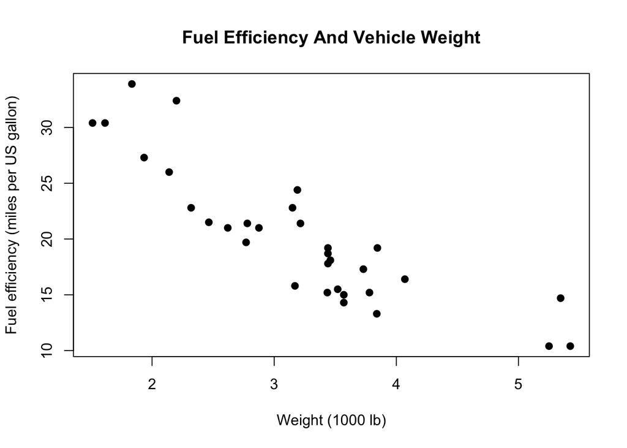

```r
stopifnot(
  nrow(cars) == 32,
  length(mpg) == nrow(cars),
  sum(is.na(mpg)) == 0,
  all(weight > 0),
  sum(lighter) + sum(heavier) == nrow(cars),
  mean_mpg_lighter > mean_mpg_heavier
)

plot(
  weight,
  mpg,
  pch = 19,
  xlab = "Weight (1000 lb)",
  ylab = "Fuel efficiency (miles per US gallon)",
  main = "Fuel Efficiency And Vehicle Weight"
)
```

```r
cat("All Week 6 basic R checks passed.\n")
```

```
All Week 6 basic R checks passed.
```

**Explain / Check / Interpret:** The source checks 32 cars, complete mpg, positive weight, a complete split and a higher observed mean mpg in the lighter group. That descriptive difference does not show weight alone caused fuel economy. With a deliberately introduced NA, mean returns NA unless an explicit missing-value rule is used; na.rm changes the observations contributing to the answer and needs an accompanying count.

### Meeting 1 in-class exit · Final five minutes

One idea that transfers from MATLAB is …

One syntax change I must remember is …

Solo readers: use the self-check below; no submission.

### Meeting 1 self-check · No submission

For the MATLAB-to-R activity, explain how you would square every value in a vector and select its first element in R. Which MATLAB punctuation must change?

**Compare the Meeting 1 self-check**

R uses x^2 for vectorized powers and x[1] for the first element. MATLAB uses x.^2 and x(1). The idea of elementwise calculation transfers; copying the punctuation does not. Run a small hand-checkable vector after translating.

## Meeting 2 · Check the claim

A plot object contains a recipe for its data and layers. `ggplot_build` exposes calculated layer data, allowing checks against intended observations. Labels must carry units: wt is in 1000 lb and mpg is miles per US gallon. A working plot can still carry an unsupported causal title.

### A checked plot is part of a reproducible argument

**Slide cues:** *Scatterplot Pattern*; *Add Meaningful Labels*; *Check The Plot Data*; *Source And Rendered Output*.

Read `ggplot(cars, aes(x = wt, y = mpg))` as the population and mappings. geom_point selects the mark, labs states meaning and units, and the theme changes presentation. The plus stays at the end of a continued line. The histogram uses a stated bin width of three mpg and counts observations in bins.

After the selected script work, open the supplied report template from the resource link below, render it unchanged, then edit the interpretation and render again. Edit the qmd source rather than its HTML output. Running one chunk does not rebuild the full report, and console-only objects are not reproducible inputs.

**Predict · Think first:** Could two scatterplots each contain 32 points but map different variables? Which additional code or layer check would expose the difference?

**Compare your reasoning**

Yes. The count checks population size, not which columns were plotted. Inspect aes and compare layer x/y against the intended variables, as the source does for wt/mpg. If your answer differed, a successful count may have been treated as evidence for the whole figure rather than one specific property.

**Try before expanding:** Use Core 6 to build the horsepower-versus-mpg plot and update its labels yourself before comparing the wt example. Think through the mappings and units before running it.

**Reference version · week06-ggplot-checks_sol.R**

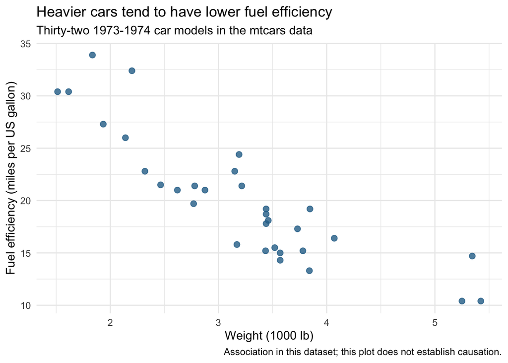

```r
# MATH 346 - possible worked solution
# Compare only after attempting the starter; other correct implementations are possible.

# MATH 346 - Week 6
# A ggplot2 workflow with data, label, and interpretation checks

library(ggplot2)
cars <- mtcars
cars$car <- rownames(mtcars)
rownames(cars) <- NULL

scatter_plot <- ggplot(cars, aes(x = wt, y = mpg)) +
  geom_point(size = 2.4, alpha = 0.8, color = "#2A6F97") +
  labs(
    title = "Heavier cars tend to have lower fuel efficiency",
    subtitle = "Thirty-two 1973-1974 car models in the mtcars data",
    x = "Weight (1000 lb)",
    y = "Fuel efficiency (miles per US gallon)",
    caption = "Association in this dataset; this plot does not establish causation."
  ) +
  theme_minimal(base_size = 12)

histogram_plot <- ggplot(cars, aes(x = mpg)) +
  geom_histogram(
    binwidth = 3,
    boundary = 0,
    color = "white",
    fill = "#E76F51"
  ) +
  labs(
    title = "Distribution of fuel efficiency",
    x = "Fuel efficiency (miles per US gallon)",
    y = "Number of car models"
  ) +
  theme_minimal(base_size = 12)

scatter_data <- ggplot_build(scatter_plot)$data[[1]]
histogram_data <- ggplot_build(histogram_plot)$data[[1]]

stopifnot(
  nrow(scatter_data) == nrow(cars),
  sum(scatter_data$x == cars$wt) == nrow(cars),
  sum(scatter_data$y == cars$mpg) == nrow(cars),
  identical(scatter_plot$labels$x, "Weight (1000 lb)"),
  identical(
    scatter_plot$labels$y,
    "Fuel efficiency (miles per US gallon)"
  ),
  sum(histogram_data$count) == nrow(cars)
)

print(scatter_plot)
```

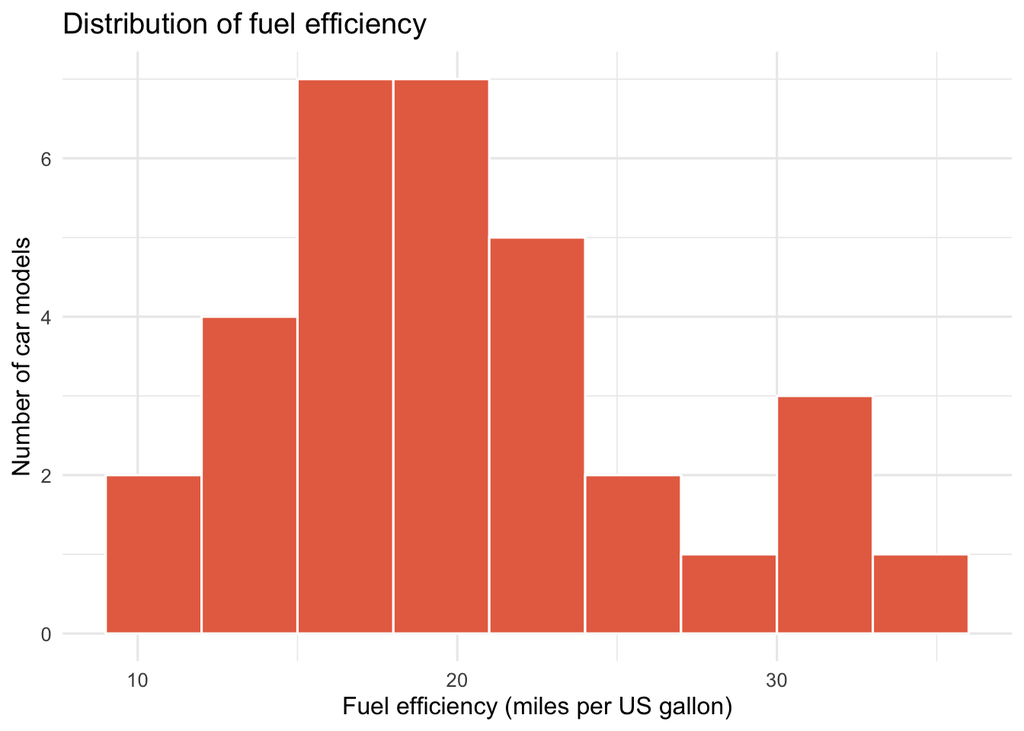

```r
print(histogram_plot)
```

```r
cat("Scatterplot rows checked:", nrow(scatter_data), "\n")
```

```
Scatterplot rows checked: 32
```

```r
cat("Histogram observations counted:", sum(histogram_data$count), "\n")
```

```
Histogram observations counted: 32
```

```r
cat("All Week 6 ggplot checks passed.\n")
```

```
All Week 6 ggplot checks passed.
```

**Explain / Check / Interpret:** The reference checks every scatter x/y value, axis labels and histogram counts. A clean-session render recreates computation, but it can also recreate the same mistake. Combine that check with known-answer arithmetic, plot-data checks and a cautious interpretation. Keep both the supplied report source and its output; course project reports still use the PDF route.

## AI audit · Inspect before accepting

**Slide cues:** *Plausible But Weak AI Plot*; *AI Audit*.

This is **selective Guided practice**; use it when selected or helpful.

Read the supplied target and choose a check before opening the diagnosis. No AI service is contacted.

Candidate checks: intended x/y mappings, 32 observations, complete variables, positive weight, labels with units, identified observations and a defensible claim. These tests have different jobs. The supplied red point colour does not encode an extra category.

**Reading excerpt:** this fragment relies on the supplied script setup; inspect it here, then run the complete file in the evidence reveal.

```r
generated_plot <- ggplot(mtcars, aes(x = wt, y = mpg)) +
  geom_point(color = "red") +
  labs(
    title = "Heavy cars cause poor fuel economy",
    x = "Weight",
    y = "Efficiency"
  )
```

**Predict in a private comment first:** What remains wrong when the generated plot runs and maps wt to mpg correctly?

**Compare your reasoning**

Its causal title exceeds observational evidence, its axes omit complete units, it omits data context and independent data checks, and red conveys no stated variable. Repair the claim to an association among the 32 1973–1974 car models in mtcars. If your answer differed, separate mapping correctness from labels, evidence and the conclusion attached to the plot.

**Run the complete supplied critique target and inspect the evidence**

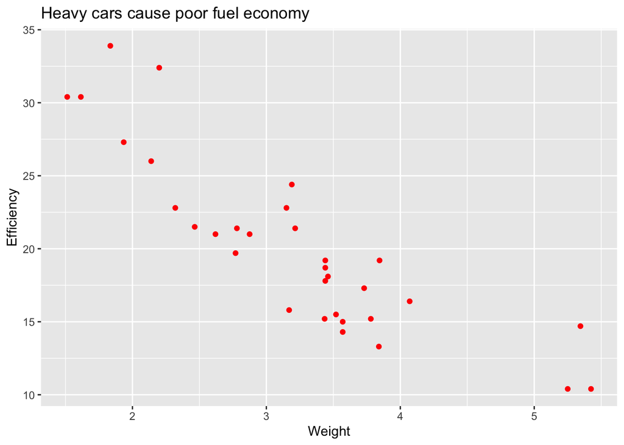

```r
# MATH 346 - Week 6
# AI plot critique starter
#
# This plot runs, but its labels and conclusion are not yet defensible.

library(ggplot2)

generated_plot <- ggplot(mtcars, aes(x = wt, y = mpg)) +
  geom_point(color = "red") +
  labs(
    title = "Heavy cars cause poor fuel economy",
    x = "Weight",
    y = "Efficiency"
  )

print(generated_plot)
```

```r
cat("Generated-code claim: heavy cars cause poor fuel economy.\n")
```

```
Generated-code claim: heavy cars cause poor fuel economy.
```

```r
# Review questions:
# 1. What units are missing from the axes?
# 2. Does an observational scatterplot establish causation?
# 3. Which cars and years does mtcars describe?
# 4. Were missing values, row count, and variable ranges checked?
# 5. What caption would accurately describe only what the plot supports?
```

Use the existing AI policy when assistance is used: explain every accepted line and keep the requested evidence with your existing work. A passing test never replaces checking whether the code answers the actual question.

### Meeting 2 in-class exit · Final five minutes

A reproducible R report is trustworthy enough to share when …

Solo readers: use the self-check below; no submission.

### Meeting 2 self-check · No submission

Close earlier reveals and explain from memory: A report renders after restarting R, but its interpretation describes horsepower while the code maps wt. Is it ready to share? Name a direct check.

**Compare the Meeting 2 self-check**

No. Reproducibility passed, but prose and evidence disagree. Inspect aes and the built x values, then align the labels and interpretation with the chosen question. Rendering regenerates code output, not an automatically correct explanation.

## Practice, recovery and resources

**Core:** 1, 2, 3, 5, 6. **Guided:** 4, 7, 8, 9. **Extension:** none.

Core 1/2/3 establish syntax and objects, Core 5 handles missingness and summaries, and Core 6 builds the horsepower plot. Report-reading/AI audits are Guided 8/9, used with the selected lab, not extra homework.

The [supplied report template](https://lnajman.github.io/math346/code/r/week06-first-report.qmd.txt) is the only report scaffold needed. Save as week06-first-report.qmd and keep its chunk markers.

Attempt the selected starter blocks before comparing possible solutions. TODO comments are placeholders, not completed analysis. Keep your checked script and follow Blackboard if a checkpoint is requested.

**If you are stuck:** inspect object classes, R brackets, missing values, and plot mappings. Run missing definitions before their first use. Keep the first error and ask for help if a focused attempt remains blocked.

- Possible solution: week06-r-basics_sol.R
- Possible solution: week06-ggplot-checks_sol.R

**Where this fits:** [Week 6 notes](https://lnajman.github.io/math346/weeks/week-06.html) · [Matching slides](https://lnajman.github.io/math346/slides/week-06.html) · [Main lab](https://lnajman.github.io/math346/labs/lab-06-rmarkdown-eda.html) · [AI-review lab](https://lnajman.github.io/math346/labs/lab-06-ai-plot-review.html) · [Exercises](https://lnajman.github.io/math346/weeks/week-06-exercises.html).